# Boston House Price Prediction

Anurima Dey

anurima10@gmail.com

## Purpose of the project:

This notebook contains the regression models for the House Price Prediction. We proceed stepwise.

### Step 1: Obtaining and cleaning the data.

The data is obtained from kaggle website.  
The displayed are the **features** of the dataset.

1. CRIM – per capita crime rate by town
2. ZN – proportion of residential land zoned for lots over 25,000 sq.ft
3. INDUS – proportion of non-retail business acres per town
4. CHAS – Charles River dummy variable (1 if tract bounds river; else 0)
5. NOX – nitric oxides concentration (parts per 10 million)
6. RM – average number of rooms per dwelling
7. AGE – proportion of owner-occupied units built prior to 1940
8. DIS – weighted distances to five Boston employment centres
9. RAD – index of accessibility to radial highways
10. TAX – full-value property-tax rate per $10,000
11. PTRATIO – pupil-teacher ratio by town
12. B – 1000(Bk - 0.63)^2 where Bk is the proportion of blacks by town
13. LSTAT – % lower status of the population
14. MEDV – Median value of owner-occupied homes in $1000’s

Read the dataset as a dataframe using read.table. After loading and cleaning the data set looks like the following.

```r
Bhousing <- read.table("housing.csv", header = FALSE, sep= "")
column_names=c('CRIM', 'ZN', 'INDUS', 'CHAS', 'NOX', 'RM',
                'AGE', 'DIS', 'RAD', 'TAX', 'PTRATIO', 'B', 'LSTAT', 'MEDV')
names(Bhousing)=column_names
head(Bhousing)
```

```
##      CRIM ZN INDUS CHAS   NOX    RM  AGE    DIS RAD TAX PTRATIO      B LSTAT
## 1 0.00632 18  2.31    0 0.538 6.575 65.2 4.0900   1 296    15.3 396.90  4.98
## 2 0.02731  0  7.07    0 0.469 6.421 78.9 4.9671   2 242    17.8 396.90  9.14
## 3 0.02729  0  7.07    0 0.469 7.185 61.1 4.9671   2 242    17.8 392.83  4.03
## 4 0.03237  0  2.18    0 0.458 6.998 45.8 6.0622   3 222    18.7 394.63  2.94
## 5 0.06905  0  2.18    0 0.458 7.147 54.2 6.0622   3 222    18.7 396.90  5.33
## 6 0.02985  0  2.18    0 0.458 6.430 58.7 6.0622   3 222    18.7 394.12  5.21
##   MEDV
## 1 24.0
## 2 21.6
## 3 34.7
## 4 33.4
## 5 36.2
## 6 28.7
```

```r
class(Bhousing)
```

```
## [1] "data.frame"
```

Now, let us check and explore the cleaned data frame containing the housing data. The **Bhousing** R object is of class ‘data.frame’.  
The **str()** function displays the structure of an R dataframe.

#### What does **str()** show:

1. The data type.
2. Name and data types of each column.
3. Some of the observations.

```r
str(Bhousing)
```

```
## 'data.frame':    506 obs. of  14 variables:
##  $ CRIM   : num  0.00632 0.02731 0.02729 0.03237 0.06905 ...
##  $ ZN     : num  18 0 0 0 0 0 12.5 12.5 12.5 12.5 ...
##  $ INDUS  : num  2.31 7.07 7.07 2.18 2.18 2.18 7.87 7.87 7.87 7.87 ...
##  $ CHAS   : int  0 0 0 0 0 0 0 0 0 0 ...
##  $ NOX    : num  0.538 0.469 0.469 0.458 0.458 0.458 0.524 0.524 0.524 0.524 ...
##  $ RM     : num  6.58 6.42 7.18 7 7.15 ...
##  $ AGE    : num  65.2 78.9 61.1 45.8 54.2 58.7 66.6 96.1 100 85.9 ...
##  $ DIS    : num  4.09 4.97 4.97 6.06 6.06 ...
##  $ RAD    : int  1 2 2 3 3 3 5 5 5 5 ...
##  $ TAX    : num  296 242 242 222 222 222 311 311 311 311 ...
##  $ PTRATIO: num  15.3 17.8 17.8 18.7 18.7 18.7 15.2 15.2 15.2 15.2 ...
##  $ B      : num  397 397 393 395 397 ...
##  $ LSTAT  : num  4.98 9.14 4.03 2.94 5.33 ...
##  $ MEDV   : num  24 21.6 34.7 33.4 36.2 28.7 22.9 27.1 16.5 18.9 ...
```

To get more detailed statistical information from each column, **summary()** function can be used. It displays the summary statistics like *minimum value, maximum value, median, mean, and the 1st and 3rd quartile* values for each column in our dataset.  
Summary also provides information about the missing values, if any is present. We see that there are no missing values in any of our variables.

```r
summary(Bhousing)
```

```
##       CRIM                ZN             INDUS            CHAS
##  Min.   : 0.00632   Min.   :  0.00   Min.   : 0.46   Min.   :0.00000
##  1st Qu.: 0.08204   1st Qu.:  0.00   1st Qu.: 5.19   1st Qu.:0.00000
##  Median : 0.25651   Median :  0.00   Median : 9.69   Median :0.00000
##  Mean   : 3.61352   Mean   : 11.36   Mean   :11.14   Mean   :0.06917
##  3rd Qu.: 3.67708   3rd Qu.: 12.50   3rd Qu.:18.10   3rd Qu.:0.00000
##  Max.   :88.97620   Max.   :100.00   Max.   :27.74   Max.   :1.00000
##       NOX               RM             AGE              DIS
##  Min.   :0.3850   Min.   :3.561   Min.   :  2.90   Min.   : 1.130
##  1st Qu.:0.4490   1st Qu.:5.886   1st Qu.: 45.02   1st Qu.: 2.100
##  Median :0.5380   Median :6.208   Median : 77.50   Median : 3.207
##  Mean   :0.5547   Mean   :6.285   Mean   : 68.57   Mean   : 3.795
##  3rd Qu.:0.6240   3rd Qu.:6.623   3rd Qu.: 94.08   3rd Qu.: 5.188
##  Max.   :0.8710   Max.   :8.780   Max.   :100.00   Max.   :12.127
##       RAD              TAX           PTRATIO            B
##  Min.   : 1.000   Min.   :187.0   Min.   :12.60   Min.   :  0.32
##  1st Qu.: 4.000   1st Qu.:279.0   1st Qu.:17.40   1st Qu.:375.38
##  Median : 5.000   Median :330.0   Median :19.05   Median :391.44
##  Mean   : 9.549   Mean   :408.2   Mean   :18.46   Mean   :356.67
##  3rd Qu.:24.000   3rd Qu.:666.0   3rd Qu.:20.20   3rd Qu.:396.23
##  Max.   :24.000   Max.   :711.0   Max.   :22.00   Max.   :396.90
##      LSTAT            MEDV
##  Min.   : 1.73   Min.   : 5.00
##  1st Qu.: 6.95   1st Qu.:17.02
##  Median :11.36   Median :21.20
##  Mean   :12.65   Mean   :22.53
##  3rd Qu.:16.95   3rd Qu.:25.00
##  Max.   :37.97   Max.   :50.00
```

We shall base our prediction mainly on the attribute MEDV (median value of the owner occupied homes) and also on other attributes that are strongly correlated to it. For the given variables and our intuition, we can feel that mnainly, DIS, RAD, LSTAT, NOX, INDUS, CRIM, TAX should have some effect on the variable MEDV. But we shall try to find out all the different types of dependencies in the next section.

### Step 2: Data Exploration and Data Visualization

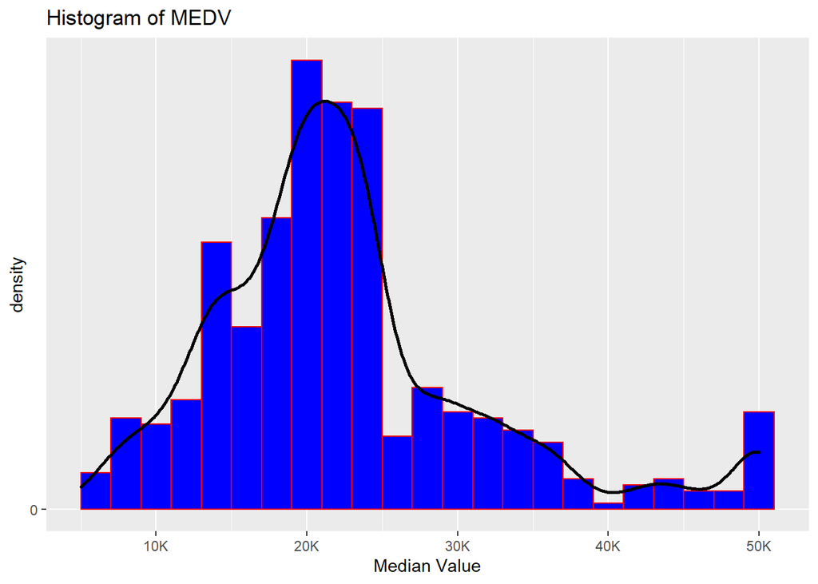

```r
library(ggplot2)

ggplot(data= Bhousing, mapping = aes(MEDV))+
  geom_histogram(aes(y=..density..), binwidth=2, color = "red", fill= "blue")+
  geom_density(size= 1 )+
  labs(title = "Histogram of MEDV", x= "Median Value", ylab= "count" )+
  scale_x_continuous(breaks = seq(0,50,10), labels = function(x){paste0(x,'K')})+
  scale_y_continuous(breaks = seq(0,80,10))
```

First thing, we try to find out density and the spread of MEDV. The previous graph shows that median value is right skewed, showing the presence of extreme values. The boxplot in the next graph also shows the same So it will be useful if we consider the log transformation to normalise the variance.

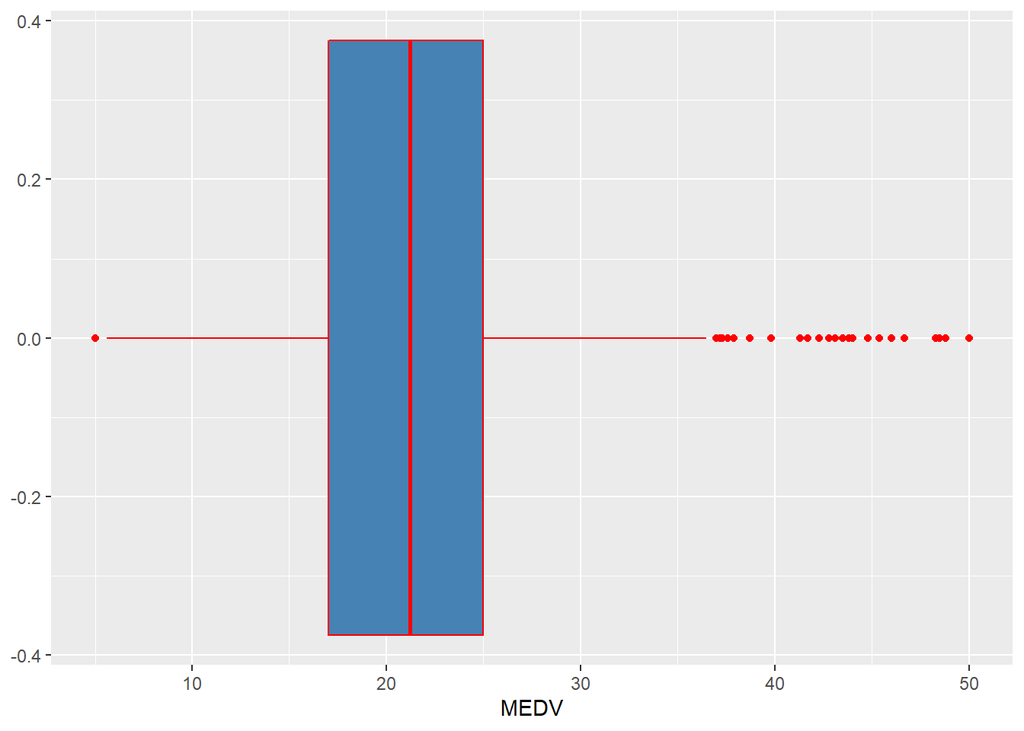

```r
ggplot(data=Bhousing, aes(MEDV))+
  geom_boxplot(color="red", fill= "steelblue")
```

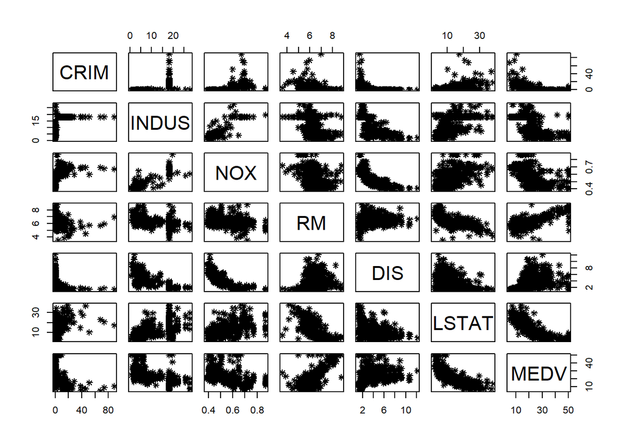

```r
plot(Bhousing[,c(1,3,5,6,8,13,14)], pch= 8)
```

We see from the last column, that MEDV has more or less a positive or negetive correlation with all other variables we have plotted. Also another thing that needs to be noticed is that all other variables are also correlated to each other. This gives us an intuition that we can probably apply dimension reducibility techniques i.e. PCA or LDA etc.

### Step 3: Finding coorelations

Let us now find out the correlation of the MEDV with the other variables. Here MEDV is our dependant variable and the rest of the variables are independent variables.

```r
cor(Bhousing, Bhousing$MEDV)
```

```
##               [,1]
## CRIM    -0.3883046
## ZN       0.3604453
## INDUS   -0.4837252
## CHAS     0.1752602
## NOX     -0.4273208
## RM       0.6953599
## AGE     -0.3769546
## DIS      0.2499287
## RAD     -0.3816262
## TAX     -0.4685359
## PTRATIO -0.5077867
## B        0.3334608
## LSTAT   -0.7376627
## MEDV     1.0000000
```

```r
rank(cor(Bhousing, Bhousing$MEDV))
```

```
##  [1]  6 12  3  9  5 13  8 10  7  4  2 11  1 14
```

The above statements show that the most negetively correlated is LSTAT and the most positily correlated is RM.

### Step 4: Feature selection and Data partitioning

Next we create the training and testing dataset. The training dataset will contain 70% of the data and the testing dataset will contain remaining 30% of the data. To do so here we use a library caret, and create data partition using inbuilt functions like createDataPartition. We could otherwise have divided the data frame manually in to first 70% and remaining 30%.

```r
library(caret)
Bhousing.scale=cbind(scale(Bhousing[1:13]), Bhousing[14])
set.seed(12345)

inTrain <- createDataPartition(y=Bhousing.scale$MEDV, p=0.70, list= F)
Bhousing.training <- Bhousing.scale[inTrain,]
Bhousing.testing <- Bhousing.scale[-inTrain,]
head(Bhousing.training)
```

```
##          CRIM          ZN      INDUS       CHAS        NOX         RM
## 1  -0.4193669  0.28454827 -1.2866362 -0.2723291 -0.1440749  0.4132629
## 3  -0.4169290 -0.48724019 -0.5927944 -0.2723291 -0.7395304  1.2814456
## 4  -0.4163384 -0.48724019 -1.3055857 -0.2723291 -0.8344581  1.0152978
## 8  -0.4032966  0.04872402 -0.4761823 -0.2723291 -0.2648919 -0.1603069
## 9  -0.3955433  0.04872402 -0.4761823 -0.2723291 -0.2648919 -0.9302853
## 10 -0.4003331  0.04872402 -0.4761823 -0.2723291 -0.2648919 -0.3994130
##           AGE      DIS        RAD        TAX    PTRATIO         B      LSTAT
## 1  -0.1198948 0.140075 -0.9818712 -0.6659492 -1.4575580 0.4406159 -1.0744990
## 3  -0.2655490 0.556609 -0.8670245 -0.9863534 -0.3027945 0.3960351 -1.2075324
## 4  -0.8090878 1.076671 -0.7521778 -1.1050216  0.1129203 0.4157514 -1.3601708
## 8   0.9778406 1.023625 -0.5224844 -0.5769480 -1.5037485 0.4406159  0.9097999
## 9   1.1163897 1.086122 -0.5224844 -0.5769480 -1.5037485 0.3281233  2.4193794
## 10  0.6154813 1.328320 -0.5224844 -0.5769480 -1.5037485 0.3289995  0.6227277
##    MEDV
## 1  24.0
## 3  34.7
## 4  33.4
## 8  27.1
## 9  16.5
## 10 18.9
```

We shall now implement various regression models and find the best one.

Let us first find out the generalised linear Regression model taking, MEDV as the dependant variable and the rest of the dataset as the dependant variable.

### Using REGRESSION

#### Model 1:

$Y= \alpha + \beta X + \epsilon$ where  
$X$: the matrix containing all the independent variables,  
$Y$: the dependant variable MEDV.  
$\epsilon$ : residual error.

```r
set.seed(12345)
lm1=lm(MEDV~., data=Bhousing.training)

sm1=summary(lm1)
sm1
```

```
##
## Call:
## lm(formula = MEDV ~ ., data = Bhousing.training)
##
## Residuals:
##      Min       1Q   Median       3Q      Max
## -16.6001  -2.7955  -0.4688   2.0113  26.0850
##
## Coefficients:
##              Estimate Std. Error t value Pr(>|t|)
## (Intercept) 22.727542   0.270166  84.124  < 2e-16 ***
## CRIM        -0.540752   0.467409  -1.157 0.248116
## ZN           0.877939   0.408393   2.150 0.032277 *
## INDUS       -0.002697   0.500689  -0.005 0.995705
## CHAS         0.652022   0.273806   2.381 0.017797 *
## NOX         -1.935714   0.580172  -3.336 0.000942 ***
## RM           2.874666   0.365992   7.854 5.24e-14 ***
## AGE          0.126333   0.456148   0.277 0.781981
## DIS         -2.987349   0.520462  -5.740 2.09e-08 ***
## RAD          2.289251   0.733496   3.121 0.001956 **
## TAX         -1.604580   0.759744  -2.112 0.035411 *
## PTRATIO     -2.014749   0.357572  -5.635 3.67e-08 ***
## B            1.079475   0.337091   3.202 0.001491 **
## LSTAT       -3.763577   0.440560  -8.543 4.39e-16 ***
## ---
## Signif. codes:  0 '***' 0.001 '**' 0.01 '*' 0.05 '.' 0.1 ' ' 1
##
## Residual standard error: 5.075 on 342 degrees of freedom
## Multiple R-squared:  0.7157, Adjusted R-squared:  0.7049
## F-statistic: 66.23 on 13 and 342 DF,  p-value: < 2.2e-16
```

```r
summary(Bhousing.testing$MEDV)
```

```
##    Min. 1st Qu.  Median    Mean 3rd Qu.    Max.
##    5.00   17.05   21.20   22.21   24.55   50.00
```

```r
pred.lm1=predict(lm1, newdata= Bhousing.testing)

summary(pred.lm1)
```

```
##    Min. 1st Qu.  Median    Mean 3rd Qu.    Max.
##   1.275  18.011  21.858  22.864  27.871  42.700
```

The summary show a significant difference in the values of the quartiles. Let us now choose the statistics that we would be using to determine the effeicienct of the model.

1. The RMSE value:

$RMSE= \sqrt{\frac{\sum(y_{pred}-y_{act})}{n}}$

The higher lower the valur of the $RMSE$ the better the prediction.

2. Correlation between actual and predicted values, higher correction implies more accuracy.
3. MaxMinAccuracy= $mean(\frac{min(actual_i,pred_i)}{max(actual_i,pred_i)})$, the greater the better.
4. Maximum Absolute Percentage Error (MAPE) : $mean(abs(\frac{pred_i-actual_i}{actual_i}))$, smaller the better.

All this can be manually calculated and compared, for the first model we shall show all of them manually, however from the next onwards we shall be using a package DMwR to find out all the regression errors and the compare among various models.

```r
actuals_predicts= data.frame(cbind(actuals=Bhousing.testing$MEDV, predicts=pred.lm1))

head(actuals_predicts)
```

```
##    actuals predicts
## 2     21.6 25.25729
## 5     36.2 28.36998
## 6     28.7 25.48950
## 7     22.9 23.03663
## 15    18.2 19.61714
## 17    23.1 20.65271
```

```r
#error 1: RMSE

RMSE(pred.lm1,Bhousing.testing$MEDV)
```

```
## [1] 4.002019
```

```r
#error 2: correlation percentage

cor(actuals_predicts$actuals, actuals_predicts$predicts)*100 #in percentage
```

```
## [1] 89.53259
```

```r
#error 3: Min_max_accuracy

mean(apply(actuals_predicts, 1, min) / apply(actuals_predicts, 1, max))*100  # in percentage
```

```
## [1] 86.71369
```

```r
#error 4: MAPE
mean(abs((actuals_predicts$predicts - actuals_predicts$actuals))/actuals_predicts$actuals)*100
```

```
## [1] 16.25696
```

```r
#using package DMwR
library(DMwR)
regr.eval(actuals_predicts$actuals,actuals_predicts$predicts)
```

```
##        mae        mse       rmse       mape
##  3.0354853 16.0161560  4.0020190  0.1625696
```

#### Regression using inbuilt library “caret”

Now we shall be using k-fold cross validation, the above performance is for this particular model, which may or may not be representative of the entire data set. So we shall carry out rigorous testing by dividing the data set into k folds and each time using one fold for testing and remaining k-1 fold for training.

The average of your k recorded errors is called the cross-validation error and will serve as your performance metric for the model.

But here we shall be using a repeated cross validation.  
In repeated cross-validation, the cross-validation procedure is repeated n times, yielding n random partitions of the original sample. The n results are again averaged (or otherwise combined) to produce a single estimation.

To do all this we shall use the “caret” library and use a inbuilt method “linear model(lm)” and also use “repeated cross validation”, dividing the data set into 10 folds and repeat 10 times.

```r
library(caret)
train_control <- trainControl(method="repeatedcv", number=10, repeats = 10)

model <- train(MEDV~., data=Bhousing, trControl=train_control, method="lm")

print(model)
```

```
## Linear Regression
##
## 506 samples
##  13 predictor
##
## No pre-processing
## Resampling: Cross-Validated (10 fold, repeated 10 times)
## Summary of sample sizes: 455, 455, 455, 456, 455, 457, ...
## Resampling results:
##
##   RMSE      Rsquared  MAE
##   4.799834  0.72985   3.386733
##
## Tuning parameter 'intercept' was held constant at a value of TRUE
```

The above summary says that:  
1. RMSE after 100 times is 4.798 (average of 100) nearly  
2. The tuning intercept is kept constant at 1 (TRUE value)

```r
names(model)
```

```
##  [1] "method"       "modelInfo"    "modelType"    "results"      "pred"
##  [6] "bestTune"     "call"         "dots"         "metric"       "control"
## [11] "finalModel"   "preProcess"   "trainingData" "resample"     "resampledCM"
## [16] "perfNames"    "maximize"     "yLimits"      "times"        "levels"
## [21] "terms"        "coefnames"    "xlevels"
```

```r
model$results
```

```
##   intercept     RMSE Rsquared      MAE    RMSESD RsquaredSD     MAESD
## 1      TRUE 4.799834  0.72985 3.386733 0.8950364 0.08978171 0.4925804
```

```r
head(model$resample)
```

```
##       RMSE  Rsquared      MAE     Resample
## 1 3.423855 0.8453354 2.744020 Fold01.Rep01
## 2 4.390694 0.7427773 3.212061 Fold02.Rep01
## 3 4.509017 0.8136803 3.156643 Fold03.Rep01
## 4 4.229568 0.7893681 3.108467 Fold04.Rep01
## 5 4.537379 0.7258107 3.296529 Fold05.Rep01
## 6 3.606000 0.7982537 2.739790 Fold06.Rep01
```

The above gives the value at each individual resample.

```r
model$finalModel
```

```
##
## Call:
## lm(formula = .outcome ~ ., data = dat)
##
## Coefficients:
## (Intercept)         CRIM           ZN        INDUS         CHAS          NOX
##   3.646e+01   -1.080e-01    4.642e-02    2.056e-02    2.687e+00   -1.777e+01
##          RM          AGE          DIS          RAD          TAX      PTRATIO
##   3.810e+00    6.922e-04   -1.476e+00    3.060e-01   -1.233e-02   -9.527e-01
##           B        LSTAT
##   9.312e-03   -5.248e-01
```

The final model selected has the following coefficients.

#### Model 2

$log(Y)=\alpha+\beta X+\epsilon$

```r
train_control <- trainControl(method="repeatedcv", number=10, repeats = 10)

model <- train(log(MEDV)~., data=Bhousing, trControl=train_control, method="lm")

print(model)
```

```
## Linear Regression
##
## 506 samples
##  13 predictor
##
## No pre-processing
## Resampling: Cross-Validated (10 fold, repeated 10 times)
## Summary of sample sizes: 456, 454, 456, 457, 455, 455, ...
## Resampling results:
##
##   RMSE       Rsquared  MAE
##   0.1934578  0.783139  0.1383911
##
## Tuning parameter 'intercept' was held constant at a value of TRUE
```

#### Model 3

$log(MEDV) = DIS+RAD+LSTAT+NOX+INDUS+CRIM+TAX$ $log(Y)=\alpha+\beta X+\epsilon$

```r
train_control <- trainControl(method="repeatedcv", number=10, repeats = 10)

model <- train(log(MEDV) ~ DIS+RAD+LSTAT+NOX+INDUS+CRIM+TAX, data=Bhousing, trControl=train_control, method="lm")

print(model)
```

```
## Linear Regression
##
## 506 samples
##   7 predictor
##
## No pre-processing
## Resampling: Cross-Validated (10 fold, repeated 10 times)
## Summary of sample sizes: 455, 456, 454, 456, 457, 456, ...
## Resampling results:
##
##   RMSE       Rsquared   MAE
##   0.2199852  0.7201472  0.1675524
##
## Tuning parameter 'intercept' was held constant at a value of TRUE
```

#### Model 4

Let us now apply PCA in this and then apply the model.

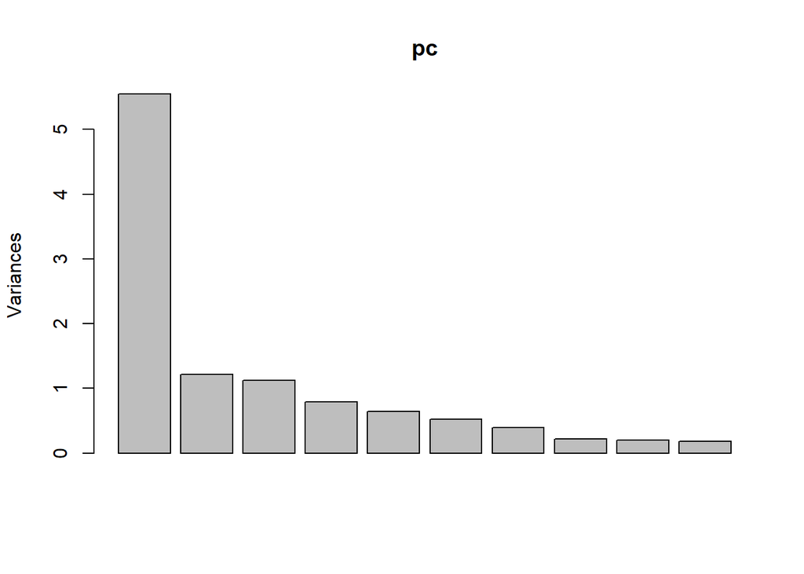

```r
Bhousing.pca=cbind(scale(Bhousing[1:3]), scale(Bhousing[5:8]), scale(Bhousing[10:13]))

pc=prcomp(Bhousing.pca, scale=FALSE)
plot(pc)
```

```r
dim(Bhousing.pca)
```

```
## [1] 506  11
```

```r
pc.pc1=as.matrix(pc$rotation[,1], nrow=length(pc$rotation[,1]))

pc.pc1
```

```
##               [,1]
## CRIM     0.2516495
## ZN      -0.2825170
## INDUS    0.3680959
## NOX      0.3629438
## RM      -0.2095785
## AGE      0.3394916
## DIS     -0.3461563
## TAX      0.3365410
## PTRATIO  0.2096055
## B       -0.2075659
## LSTAT    0.3321957
```

```r
model4.pc1=Bhousing.pca%*%pc.pc1
dim(model4.pc1)
```

```
## [1] 506   1
```

```r
pc.data=data.frame(pc1=model4.pc1, CHAS=Bhousing$CHAS, RAD=Bhousing$RAD, MEDV=Bhousing$MEDV)

head(pc.data)
```

```
##         pc1 CHAS RAD MEDV
## 1 -1.865654    0   1 24.0
## 2 -1.212999    0   2 21.6
## 3 -1.884025    0   2 34.7
## 4 -2.497075    0   3 33.4
## 5 -2.333117    0   3 36.2
## 6 -2.065384    0   3 28.7
```

```r
train_control <- trainControl(method="repeatedcv", number=10, repeats = 10)

model <- train(log(MEDV) ~ pc1, data=pc.data, trControl=train_control, method="lm")

print(model)
```

```
## Linear Regression
##
## 506 samples
##   1 predictor
##
## No pre-processing
## Resampling: Cross-Validated (10 fold, repeated 10 times)
## Summary of sample sizes: 456, 455, 456, 458, 455, 455, ...
## Resampling results:
##
##   RMSE       Rsquared   MAE
##   0.2861122  0.5158076  0.2124698
##
## Tuning parameter 'intercept' was held constant at a value of TRUE
```

Thus comparing the four models we see that the model 2 is the best. However certain tunings can be still carried out in model 4.

Thank you